# Modelos Lineares Generalizados(MLG)

joseferson da silva barreto e Antonio

2022-10-12

# Objetivo

# Metodologia

### Definindo o Problema de Negócio

Nosso objetivo é construir um modelo de regressão generalizado que seja capaz de explicar quais características influenciam na precificação do automovel. A variável a ser prevista é um valor numérico que representa o preço de cada automovel observado. Para cada automóvel temos diversas variáveis explanatórias. Sendo assim, podemos buscar resolver este problema utilizando MLG.

### Definindo o Dataset

Este conjunto de dados consiste em dados do Anuário Automotivo da Ward de 1985. Aqui estão as fontes

Fontes:

1. 1985 Modelo de Importação de Carro e Especificações de Caminhão, Anuário Automotivo de 1985 Ward.
2. Personal Auto Manuals, Insurance Services Office, 160 Water Street, Nova York, NY 10038
3. Insurance Collision Report, Insurance Institute for Highway Safety, Watergate 600, Washington, DC 20037

Esse conjunto de dados consiste em três tipos de entidades: (a) a especificação de um automóvel em termos de várias características, (b) sua classificação de risco de seguro atribuída, (c) suas perdas normalizadas em uso em comparação com outros carros. A segunda classificação corresponde ao grau em que o automóvel é mais arriscado do que seu preço indica. Os carros recebem inicialmente um símbolo de fator de risco associado ao seu preço. Então, se for mais arriscado (ou menos), esse símbolo é ajustado movendo-o para cima (ou para baixo) na escala. Os atuários chamam esse processo de “simbolização”. Um valor de +3 indica que o automóvel é arriscado, -3 que provavelmente é bastante seguro.

O terceiro fator é o pagamento de perda média relativa por ano de veículo segurado. Este valor é normalizado para todos os automóveis dentro de uma determinada classificação de tamanho (pequeno de duas portas, carrinhas, desporto/especialidade, etc…), e representa a perda média por automóvel por ano.

Nota: Vários dos atributos no banco de dados podem ser usados como um atributo de “classe”.

# Introdução

[figure not shown]

O primeiro meio de transporte a fazer uso de um motor a gasolina para se locomover foi um automóvel que continha somente três rodas e foi criado no ano de 1885 por um alemão de nome Karl Benz.A partir de então teve início a corrida pela produção e venda de automóveis, iniciada por uma empresa francesa conhecida pelo nome de Panhard et Levassor. No ano de 1892, o conhecido Henry Ford fabricou seu primeiro carro, o Ford, na América do Norte.Estima-se que a quantidade de autóveis no Brasil já ultrapassa a casa dos 11 milhões de veículos, segundo o senado, Dados da Secretaria Nacional de Trânsito do Ministério da Infraestrutura indicam haver mais de 3,5 milhões de caminhões em circulação no Brasil e, desse total, cerca de 26% dos veículos possuem mais de 30 anos de fabricação, a expectativa é que esse número aumente ainda mais nós próximos anos. Neste material buscaremos criar um modelo capaz de explicar quais fatores influenciar no preço do automóvel, para este fim sera utilizado os modelos lineares generalizados.

Os modelos lineares Generalizados são utilizados quando utilizar os modelos clássicos que pressupoem que os dados seguem uma distribuição normal e principalmente onde temos dados que segue uma base de dados discretos . O princípio do GLM é pegar uma família de distribuições ao ínves de uma única distribuição que no nosso caso será a famíla exponencial , ou sejá , ao ínves de trabalhar apenas com a normal , trabalhamos com várias distribuições : gamma,expenencial,poisson ,binomial,binomial negativa,weibell. Um estudo de regressão busca,essencialmente,associar uma variável **Y** (denominada variável dependente)a uma outra variável **X** (denominada variável explanatória ou variável independente ).

## Partes de Um MLG

1. $Y_{i} \sim p(y | \theta) \rightarrow E(y_{i}) = \mu_{i}$
2. $n_{i} = g(\mu_{i})$
3. $n_{i} = \beta_{0} + \beta_{1} *x_{I}$

# Conhecendo o Nossos Dados

## Análises Descritivas

### Banco de Dados

```r
library(readr)
dados <- read_csv("carrosTrat.csv",
    col_types = cols(stroke = col_double()))
dados$price<-as.numeric(dados$price)
head (dados)
```

```
## # A tibble: 6 × 26
##   symboling normalized.losses make  fuel.type aspiration num.of.doors body.style
##       <dbl>             <dbl> <chr> <chr>     <chr>      <chr>        <chr>
## 1         3               115 alfa… gas       std        two          convertib…
## 2         3               115 alfa… gas       std        two          convertib…
## 3         1               115 alfa… gas       std        two          hatchback
## 4         2               164 audi  gas       std        four         sedan
## 5         2               164 audi  gas       std        four         sedan
## 6         2               115 audi  gas       std        two          sedan
## # … with 19 more variables: drive.wheels <chr>, engine.location <chr>,
## #   wheel.base <dbl>, length <dbl>, width <dbl>, height <dbl>,
## #   curb.weight <dbl>, engine.type <chr>, num.of.cylinders <chr>,
## #   engine.size <dbl>, fuel.system <chr>, bore <dbl>, stroke <dbl>,
## #   compression.ratio <dbl>, horsepower <dbl>, peak.rpm <dbl>, city.mpg <dbl>,
## #   highway.mpg <dbl>, price <dbl>
```

### Dados Faltantes NA’s

```r
round(mean(is.na(dados))*100,10)
```

```
## [1] 0.0750469
```

Tem a presença de 0.075% de dados faltantes, analisando onde ele se encontra:

```r
library(skimr)
skim(dados)
```

Data summary

| Name | dados |
| --- | --- |
| Number of rows | 205 |
| Number of columns | 26 |
| _______________________ |  |
| Column type frequency: |  |
| character | 10 |
| numeric | 16 |
| ________________________ |  |
| Group variables | None |

**Variable type: character**

| skim_variable | n_missing | complete_rate | min | max | empty | n_unique | whitespace |
| --- | --- | --- | --- | --- | --- | --- | --- |
| make | 0 | 1 | 3 | 13 | 0 | 22 | 0 |
| fuel.type | 0 | 1 | 3 | 6 | 0 | 2 | 0 |
| aspiration | 0 | 1 | 3 | 5 | 0 | 2 | 0 |
| num.of.doors | 0 | 1 | 1 | 4 | 0 | 3 | 0 |
| body.style | 0 | 1 | 5 | 11 | 0 | 5 | 0 |
| drive.wheels | 0 | 1 | 3 | 3 | 0 | 3 | 0 |
| engine.location | 0 | 1 | 4 | 5 | 0 | 2 | 0 |
| engine.type | 0 | 1 | 1 | 5 | 0 | 7 | 0 |
| num.of.cylinders | 0 | 1 | 3 | 6 | 0 | 7 | 0 |
| fuel.system | 0 | 1 | 3 | 4 | 0 | 8 | 0 |

**Variable type: numeric**

| skim_variable | n_missing | complete_rate | mean | sd | p0 | p25 | p50 | p75 | p100 | hist |
| --- | --- | --- | --- | --- | --- | --- | --- | --- | --- | --- |
| symboling | 0 | 1.00 | 0.83 | 1.25 | -2.00 | 0.00 | 1.00 | 2.00 | 3.00 | ▃▇▆▃▃ |
| normalized.losses | 0 | 1.00 | 120.60 | 31.81 | 65.00 | 101.00 | 115.00 | 137.00 | 256.00 | ▆▇▃▁▁ |
| wheel.base | 0 | 1.00 | 98.76 | 6.02 | 86.60 | 94.50 | 97.00 | 102.40 | 120.90 | ▁▇▂▁▁ |
| length | 0 | 1.00 | 174.05 | 12.34 | 141.10 | 166.30 | 173.20 | 183.10 | 208.10 | ▁▅▇▃▁ |
| width | 0 | 1.00 | 65.91 | 2.15 | 60.30 | 64.10 | 65.50 | 66.90 | 72.30 | ▁▇▇▂▁ |
| height | 0 | 1.00 | 53.72 | 2.44 | 47.80 | 52.00 | 54.10 | 55.50 | 59.80 | ▁▆▇▆▂ |
| curb.weight | 0 | 1.00 | 2555.57 | 520.68 | 1488.00 | 2145.00 | 2414.00 | 2935.00 | 4066.00 | ▃▇▅▃▁ |
| engine.size | 0 | 1.00 | 126.91 | 41.64 | 61.00 | 97.00 | 120.00 | 141.00 | 326.00 | ▇▆▂▁▁ |
| bore | 0 | 1.00 | 3.33 | 0.27 | 2.54 | 3.15 | 3.31 | 3.58 | 3.94 | ▁▅▇▇▂ |
| stroke | 4 | 0.98 | 3.26 | 0.32 | 2.07 | 3.11 | 3.29 | 3.41 | 4.17 | ▁▂▇▇▁ |
| compression.ratio | 0 | 1.00 | 10.14 | 3.97 | 7.00 | 8.60 | 9.00 | 9.40 | 23.00 | ▇▁▁▁▁ |
| horsepower | 0 | 1.00 | 104.17 | 39.53 | 48.00 | 70.00 | 95.00 | 116.00 | 288.00 | ▇▅▂▁▁ |
| peak.rpm | 0 | 1.00 | 5126.10 | 477.04 | 4150.00 | 4800.00 | 5200.00 | 5500.00 | 6600.00 | ▂▇▇▂▁ |
| city.mpg | 0 | 1.00 | 25.22 | 6.54 | 13.00 | 19.00 | 24.00 | 30.00 | 49.00 | ▆▇▅▂▁ |
| highway.mpg | 0 | 1.00 | 30.75 | 6.89 | 16.00 | 25.00 | 30.00 | 34.00 | 54.00 | ▂▇▆▁▁ |
| price | 0 | 1.00 | 13150.31 | 7879.12 | 5118.00 | 7788.00 | 10295.00 | 16500.00 | 45400.00 | ▇▃▁▁▁ |

Observe que os dados faltantes se encontram em **STROKE** (derramamento de óleo), eles precisam ser tratados:

```r
dados[is.na(dados$stroke),]$stroke = median(dados$stroke,na.rm = T)
```

### Foi atribuido para cada valor faltante a sua mediana da coluna, agora poderá seguir com o restante da análise dos dados.

### Histograma e Normalidade

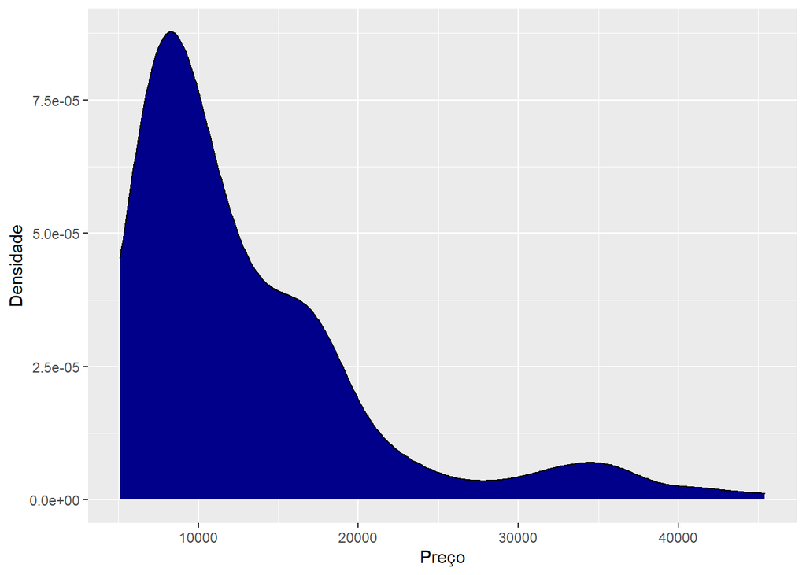

```r
library(ggplot2)
dados %>% ggplot(aes(price))+
  geom_density(fill = "darkblue")+
  labs(x= "Preço", y="Densidade")
```

```r
shapiro.test(dados$price)
```

```
##
##  Shapiro-Wilk normality test
##
## data:  dados$price
## W = 0.79542, p-value = 1.145e-15
```

Pelo teste de normalidade univariada de Shapiro-Wilk, o valor deu menor que 0.05, então os dados de preço não seguem a normalidade dos resíduos.

```r
library(skimr)
skim(dados)
```

Data summary

| Name | dados |
| --- | --- |
| Number of rows | 205 |
| Number of columns | 26 |
| _______________________ |  |
| Column type frequency: |  |
| character | 10 |
| numeric | 16 |
| ________________________ |  |
| Group variables | None |

**Variable type: character**

| skim_variable | n_missing | complete_rate | min | max | empty | n_unique | whitespace |
| --- | --- | --- | --- | --- | --- | --- | --- |
| make | 0 | 1 | 3 | 13 | 0 | 22 | 0 |
| fuel.type | 0 | 1 | 3 | 6 | 0 | 2 | 0 |
| aspiration | 0 | 1 | 3 | 5 | 0 | 2 | 0 |
| num.of.doors | 0 | 1 | 1 | 4 | 0 | 3 | 0 |
| body.style | 0 | 1 | 5 | 11 | 0 | 5 | 0 |
| drive.wheels | 0 | 1 | 3 | 3 | 0 | 3 | 0 |
| engine.location | 0 | 1 | 4 | 5 | 0 | 2 | 0 |
| engine.type | 0 | 1 | 1 | 5 | 0 | 7 | 0 |
| num.of.cylinders | 0 | 1 | 3 | 6 | 0 | 7 | 0 |
| fuel.system | 0 | 1 | 3 | 4 | 0 | 8 | 0 |

**Variable type: numeric**

| skim_variable | n_missing | complete_rate | mean | sd | p0 | p25 | p50 | p75 | p100 | hist |
| --- | --- | --- | --- | --- | --- | --- | --- | --- | --- | --- |
| symboling | 0 | 1 | 0.83 | 1.25 | -2.00 | 0.00 | 1.00 | 2.00 | 3.00 | ▃▇▆▃▃ |
| normalized.losses | 0 | 1 | 120.60 | 31.81 | 65.00 | 101.00 | 115.00 | 137.00 | 256.00 | ▆▇▃▁▁ |
| wheel.base | 0 | 1 | 98.76 | 6.02 | 86.60 | 94.50 | 97.00 | 102.40 | 120.90 | ▁▇▂▁▁ |
| length | 0 | 1 | 174.05 | 12.34 | 141.10 | 166.30 | 173.20 | 183.10 | 208.10 | ▁▅▇▃▁ |
| width | 0 | 1 | 65.91 | 2.15 | 60.30 | 64.10 | 65.50 | 66.90 | 72.30 | ▁▇▇▂▁ |
| height | 0 | 1 | 53.72 | 2.44 | 47.80 | 52.00 | 54.10 | 55.50 | 59.80 | ▁▆▇▆▂ |
| curb.weight | 0 | 1 | 2555.57 | 520.68 | 1488.00 | 2145.00 | 2414.00 | 2935.00 | 4066.00 | ▃▇▅▃▁ |
| engine.size | 0 | 1 | 126.91 | 41.64 | 61.00 | 97.00 | 120.00 | 141.00 | 326.00 | ▇▆▂▁▁ |
| bore | 0 | 1 | 3.33 | 0.27 | 2.54 | 3.15 | 3.31 | 3.58 | 3.94 | ▁▅▇▇▂ |
| stroke | 0 | 1 | 3.26 | 0.31 | 2.07 | 3.11 | 3.29 | 3.41 | 4.17 | ▁▂▇▇▁ |
| compression.ratio | 0 | 1 | 10.14 | 3.97 | 7.00 | 8.60 | 9.00 | 9.40 | 23.00 | ▇▁▁▁▁ |
| horsepower | 0 | 1 | 104.17 | 39.53 | 48.00 | 70.00 | 95.00 | 116.00 | 288.00 | ▇▅▂▁▁ |
| peak.rpm | 0 | 1 | 5126.10 | 477.04 | 4150.00 | 4800.00 | 5200.00 | 5500.00 | 6600.00 | ▂▇▇▂▁ |
| city.mpg | 0 | 1 | 25.22 | 6.54 | 13.00 | 19.00 | 24.00 | 30.00 | 49.00 | ▆▇▅▂▁ |
| highway.mpg | 0 | 1 | 30.75 | 6.89 | 16.00 | 25.00 | 30.00 | 34.00 | 54.00 | ▂▇▆▁▁ |
| price | 0 | 1 | 13150.31 | 7879.12 | 5118.00 | 7788.00 | 10295.00 | 16500.00 | 45400.00 | ▇▃▁▁▁ |

## Análise Exploratória

O ponta pé inicial de qualquer análise é a análise exploratória, com ela começas a entender a grandeza dos nossos dados e os seus comportamentos, dessa forma, vamos carregar os pacotes necessários e executar a análise exploratória:

```r
library(tidyverse)
library(DT)
library(readxl)


dados<-read.table("dados.txt",sep = ",",header = TRUE)
```

Vamos verificar se nosso conjunto de dados pussui valores ausentes, caso tenhamos, teremos que remover essas observações

```r
sum(dados[!complete.cases(dados),])
```

```
## [1] 0
```

Como podemos ver o nosso conjunto de dados não apresentou nenhum valor faltante, logo, podemos prosseguir da forma que está.

### Observando a Grandeza dos Nossos Dados

Para verificar a grandeza dos nossos dados vamos utilizar o seguinte comando:

```r
glimpse(dados)
```

```
## Rows: 205
## Columns: 26
## $ symboling         <int> 3, 3, 1, 2, 2, 2, 1, 1, 1, 0, 2, 0, 0, 0, 1, 0, 0, 0…
## $ normalized.losses <chr> "?", "?", "?", "164", "164", "?", "158", "?", "158",…
## $ make              <chr> "alfa-romero", "alfa-romero", "alfa-romero", "audi",…
## $ fuel.type         <chr> "gas", "gas", "gas", "gas", "gas", "gas", "gas", "ga…
## $ aspiration        <chr> "std", "std", "std", "std", "std", "std", "std", "st…
## $ num.of.doors      <chr> "two", "two", "two", "four", "four", "two", "four", …
## $ body.style        <chr> "convertible", "convertible", "hatchback", "sedan", …
## $ drive.wheels      <chr> "rwd", "rwd", "rwd", "fwd", "4wd", "fwd", "fwd", "fw…
## $ engine.location   <chr> "front", "front", "front", "front", "front", "front"…
## $ wheel.base        <dbl> 88.6, 88.6, 94.5, 99.8, 99.4, 99.8, 105.8, 105.8, 10…
## $ length            <dbl> 168.8, 168.8, 171.2, 176.6, 176.6, 177.3, 192.7, 192…
## $ width             <dbl> 64.1, 64.1, 65.5, 66.2, 66.4, 66.3, 71.4, 71.4, 71.4…
## $ height            <dbl> 48.8, 48.8, 52.4, 54.3, 54.3, 53.1, 55.7, 55.7, 55.9…
## $ curb.weight       <int> 2548, 2548, 2823, 2337, 2824, 2507, 2844, 2954, 3086…
## $ engine.type       <chr> "dohc", "dohc", "ohcv", "ohc", "ohc", "ohc", "ohc", …
## $ num.of.cylinders  <chr> "four", "four", "six", "four", "five", "five", "five…
## $ engine.size       <int> 130, 130, 152, 109, 136, 136, 136, 136, 131, 131, 10…
## $ fuel.system       <chr> "mpfi", "mpfi", "mpfi", "mpfi", "mpfi", "mpfi", "mpf…
## $ bore              <chr> "3.47", "3.47", "2.68", "3.19", "3.19", "3.19", "3.1…
## $ stroke            <chr> "2.68", "2.68", "3.47", "3.40", "3.40", "3.40", "3.4…
## $ compression.ratio <dbl> 9.00, 9.00, 9.00, 10.00, 8.00, 8.50, 8.50, 8.50, 8.3…
## $ horsepower        <chr> "111", "111", "154", "102", "115", "110", "110", "11…
## $ peak.rpm          <chr> "5000", "5000", "5000", "5500", "5500", "5500", "550…
## $ city.mpg          <int> 21, 21, 19, 24, 18, 19, 19, 19, 17, 16, 23, 23, 21, …
## $ highway.mpg       <int> 27, 27, 26, 30, 22, 25, 25, 25, 20, 22, 29, 29, 28, …
## $ price             <chr> "13495", "16500", "16500", "13950", "17450", "15250"…
```

Como podemos ver a maioria das variáveis não estão no formato adequado,vamos ter que converte-las para fatores as que são referentes a fatores e numericos a referente a valores númericos

### Transformações de Variáveis

Vamos utilizar a função **mutate_if** para colocar a condição de transformação das colunas, por exemplo , no primeiro código abaixo as culanas de dados da coluna 3 a coluna 9 que são do tipo character serão convertidas para factor , os demais códigos abaixo seguem as mesmas linhas de raciocínio.

```r
dados[3:9]<-dados[3:9] %>% mutate_if(is.character,as.factor)

dados[15:16]<-dados[15:16] %>% mutate_if(is.character,as.factor)



dados[18]<-dados[18] %>% mutate_if(is.character,as.factor)


dados[20]<-dados[20] %>% mutate_if(is.character,as.factor)

dados$compression.ratio[dados$compression.ratio == "?"] <- "NA"

dados<-dados %>% mutate_if(is.character,as.numeric)
```

Vamos observar os nossos dados

```r
library(gt)
# dados |> datatable(
#           rownames = FALSE,
#           options = list(
#             columnDefs = list(list(className = 'dt-center', targets = 0:4))
#             )
#           )






dados |> head(10) |> gt()
```

| symboling | normalized.losses | make | fuel.type | aspiration | num.of.doors | body.style | drive.wheels | engine.location | wheel.base | length | width | height | curb.weight | engine.type | num.of.cylinders | engine.size | fuel.system | bore | stroke | compression.ratio | horsepower | peak.rpm | city.mpg | highway.mpg | price |
| --- | --- | --- | --- | --- | --- | --- | --- | --- | --- | --- | --- | --- | --- | --- | --- | --- | --- | --- | --- | --- | --- | --- | --- | --- | --- |
| 3 | NA | alfa-romero | gas | std | two | convertible | rwd | front | 88.6 | 168.8 | 64.1 | 48.8 | 2548 | dohc | four | 130 | mpfi | 3.47 | 2.68 | 9.0 | 111 | 5000 | 21 | 27 | 13495 |
| 3 | NA | alfa-romero | gas | std | two | convertible | rwd | front | 88.6 | 168.8 | 64.1 | 48.8 | 2548 | dohc | four | 130 | mpfi | 3.47 | 2.68 | 9.0 | 111 | 5000 | 21 | 27 | 16500 |
| 1 | NA | alfa-romero | gas | std | two | hatchback | rwd | front | 94.5 | 171.2 | 65.5 | 52.4 | 2823 | ohcv | six | 152 | mpfi | 2.68 | 3.47 | 9.0 | 154 | 5000 | 19 | 26 | 16500 |
| 2 | 164 | audi | gas | std | four | sedan | fwd | front | 99.8 | 176.6 | 66.2 | 54.3 | 2337 | ohc | four | 109 | mpfi | 3.19 | 3.40 | 10.0 | 102 | 5500 | 24 | 30 | 13950 |
| 2 | 164 | audi | gas | std | four | sedan | 4wd | front | 99.4 | 176.6 | 66.4 | 54.3 | 2824 | ohc | five | 136 | mpfi | 3.19 | 3.40 | 8.0 | 115 | 5500 | 18 | 22 | 17450 |
| 2 | NA | audi | gas | std | two | sedan | fwd | front | 99.8 | 177.3 | 66.3 | 53.1 | 2507 | ohc | five | 136 | mpfi | 3.19 | 3.40 | 8.5 | 110 | 5500 | 19 | 25 | 15250 |
| 1 | 158 | audi | gas | std | four | sedan | fwd | front | 105.8 | 192.7 | 71.4 | 55.7 | 2844 | ohc | five | 136 | mpfi | 3.19 | 3.40 | 8.5 | 110 | 5500 | 19 | 25 | 17710 |
| 1 | NA | audi | gas | std | four | wagon | fwd | front | 105.8 | 192.7 | 71.4 | 55.7 | 2954 | ohc | five | 136 | mpfi | 3.19 | 3.40 | 8.5 | 110 | 5500 | 19 | 25 | 18920 |
| 1 | 158 | audi | gas | turbo | four | sedan | fwd | front | 105.8 | 192.7 | 71.4 | 55.9 | 3086 | ohc | five | 131 | mpfi | 3.13 | 3.40 | 8.3 | 140 | 5500 | 17 | 20 | 23875 |
| 0 | NA | audi | gas | turbo | two | hatchback | 4wd | front | 99.5 | 178.2 | 67.9 | 52.0 | 3053 | ohc | five | 131 | mpfi | 3.13 | 3.40 | 7.0 | 160 | 5500 | 16 | 22 | NA |

Podemos perceber que após as transformações temos a presença de valores ausentes,teremos que tratar esses valores ausentes

### Trantando valores ausentes nas variáveis númericas

```r
# symboling é fator ,mas vai permanecer como númerica


# subiistituindo os valores ausentes pelo valor mediano

dados[is.na(dados$normalized.losses),]$normalized.losses =median(dados$normalized.losses,na.rm = T)

dados[is.na(dados$price),]$price = median(dados$price,na.rm = T)


dados$stroke[dados$stroke == "?"] <- "NA"
dados$stroke<-as.numeric(dados$stroke)

dados[is.na(dados$stroke),]$stroke = median(dados$stroke,na.rm = T)


dados[is.na(dados$bore),]$bore = median(dados$bore,na.rm = T)

#dados$compression.ratio[dados$compression.ratio == "?"] <- "NA"



dados$compression.ratio<-as.double(dados$compression.ratio)
#dados[is.na(dados$compression.ratio),]$compression.ratio = median(dados$compression.ratio,na.rm = T)
dados[is.na(dados$horsepower),]$horsepower= median(dados$horsepower,na.rm = T)

dados[is.na(dados$peak.rpm),]$peak.rpm= median(dados$peak.rpm,na.rm = T)
```

### Verificando se Ainda temos Algum Valor Ausente

```r
colnms <- colnames(dados)

# filter
teste<-dados %>%
  filter_at(vars(all_of(colnms)), any_vars(is.na(.)))

sum(teste)
```

```
## [1] 0
```

Como podemos ver não temos mais a presença de valores ausentes, podemos prosseguir.

Vamos observar novamente nossos dados

```r
library(gt)
# dados |> datatable(
#           rownames = FALSE,
#           options = list(
#             columnDefs = list(list(className = 'dt-center', targets = 0:4))
#             )
#           )






dados |> head(10) |> gt()
```

| symboling | normalized.losses | make | fuel.type | aspiration | num.of.doors | body.style | drive.wheels | engine.location | wheel.base | length | width | height | curb.weight | engine.type | num.of.cylinders | engine.size | fuel.system | bore | stroke | compression.ratio | horsepower | peak.rpm | city.mpg | highway.mpg | price |
| --- | --- | --- | --- | --- | --- | --- | --- | --- | --- | --- | --- | --- | --- | --- | --- | --- | --- | --- | --- | --- | --- | --- | --- | --- | --- |
| 3 | 115 | alfa-romero | gas | std | two | convertible | rwd | front | 88.6 | 168.8 | 64.1 | 48.8 | 2548 | dohc | four | 130 | mpfi | 3.47 | 6 | 9.0 | 111 | 5000 | 21 | 27 | 13495 |
| 3 | 115 | alfa-romero | gas | std | two | convertible | rwd | front | 88.6 | 168.8 | 64.1 | 48.8 | 2548 | dohc | four | 130 | mpfi | 3.47 | 6 | 9.0 | 111 | 5000 | 21 | 27 | 16500 |
| 1 | 115 | alfa-romero | gas | std | two | hatchback | rwd | front | 94.5 | 171.2 | 65.5 | 52.4 | 2823 | ohcv | six | 152 | mpfi | 2.68 | 29 | 9.0 | 154 | 5000 | 19 | 26 | 16500 |
| 2 | 164 | audi | gas | std | four | sedan | fwd | front | 99.8 | 176.6 | 66.2 | 54.3 | 2337 | ohc | four | 109 | mpfi | 3.19 | 26 | 10.0 | 102 | 5500 | 24 | 30 | 13950 |
| 2 | 164 | audi | gas | std | four | sedan | 4wd | front | 99.4 | 176.6 | 66.4 | 54.3 | 2824 | ohc | five | 136 | mpfi | 3.19 | 26 | 8.0 | 115 | 5500 | 18 | 22 | 17450 |
| 2 | 115 | audi | gas | std | two | sedan | fwd | front | 99.8 | 177.3 | 66.3 | 53.1 | 2507 | ohc | five | 136 | mpfi | 3.19 | 26 | 8.5 | 110 | 5500 | 19 | 25 | 15250 |
| 1 | 158 | audi | gas | std | four | sedan | fwd | front | 105.8 | 192.7 | 71.4 | 55.7 | 2844 | ohc | five | 136 | mpfi | 3.19 | 26 | 8.5 | 110 | 5500 | 19 | 25 | 17710 |
| 1 | 115 | audi | gas | std | four | wagon | fwd | front | 105.8 | 192.7 | 71.4 | 55.7 | 2954 | ohc | five | 136 | mpfi | 3.19 | 26 | 8.5 | 110 | 5500 | 19 | 25 | 18920 |
| 1 | 158 | audi | gas | turbo | four | sedan | fwd | front | 105.8 | 192.7 | 71.4 | 55.9 | 3086 | ohc | five | 131 | mpfi | 3.13 | 26 | 8.3 | 140 | 5500 | 17 | 20 | 23875 |
| 0 | 115 | audi | gas | turbo | two | hatchback | 4wd | front | 99.5 | 178.2 | 67.9 | 52.0 | 3053 | ohc | five | 131 | mpfi | 3.13 | 26 | 7.0 | 160 | 5500 | 16 | 22 | 10295 |

### Vendo as Correlações das Variáveis Númericas

Problemas de multicolinearidade são muitos comuns em modelos de regressão,isso acaba prejudicando o modelo, devido a este fato vamos verificar a correção entre as variáveis preditoras, e depois vamos verificar quais variaveis remover, para verificar a correlação vamos executar o gráfico de correlação de pearson através do comando abaixo:

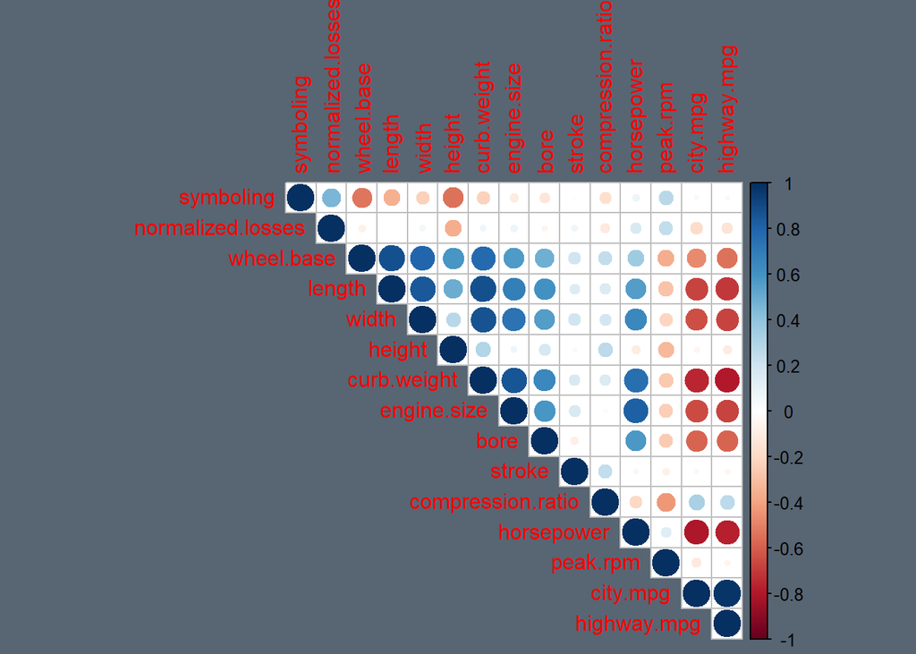

```r
library(corrplot)
par(bg = '#586573')
dados[-26] |>
  dplyr::select(where(is.numeric))  |>
  cor( ) |>
corrplot::corrplot( type = "upper")
```

Como podemos ver várias colunas apresentaram correlação,logo teremos que remove-lás

### Verificando Presença de Multicolinearidade das Variáveis Númericas

```r
library(caret)

t<-dados[-26] |>
  dplyr::select(where(is.numeric))

 t[-1] %>%
  cor() %>%
  findCorrelation( cutoff = .50, verbose = FALSE)
```

```
## [1]  6  3  4 14  2 13  7 11
```

Logo, essas as variáveis cotadas para remoção ,mas antes disso vamos ver se temos colunas com repetidas

### Verificando se Temos Colunas Identicas

```r
t[-1] %>%
  cor() %>%  findLinearCombos ()
```

```
## $linearCombos
## list()
##
## $remove
## NULL
```

```r
t<-dados[-1] |>
  dplyr::select(where(is.numeric))

glimpse(t)
```

```
## Rows: 205
## Columns: 15
## $ normalized.losses <dbl> 115, 115, 115, 164, 164, 115, 158, 115, 158, 115, 19…
## $ wheel.base        <dbl> 88.6, 88.6, 94.5, 99.8, 99.4, 99.8, 105.8, 105.8, 10…
## $ length            <dbl> 168.8, 168.8, 171.2, 176.6, 176.6, 177.3, 192.7, 192…
## $ width             <dbl> 64.1, 64.1, 65.5, 66.2, 66.4, 66.3, 71.4, 71.4, 71.4…
## $ height            <dbl> 48.8, 48.8, 52.4, 54.3, 54.3, 53.1, 55.7, 55.7, 55.9…
## $ curb.weight       <int> 2548, 2548, 2823, 2337, 2824, 2507, 2844, 2954, 3086…
## $ engine.size       <int> 130, 130, 152, 109, 136, 136, 136, 136, 131, 131, 10…
## $ bore              <dbl> 3.47, 3.47, 2.68, 3.19, 3.19, 3.19, 3.19, 3.19, 3.13…
## $ stroke            <dbl> 6, 6, 29, 26, 26, 26, 26, 26, 26, 26, 8, 8, 19, 19, …
## $ compression.ratio <dbl> 9.00, 9.00, 9.00, 10.00, 8.00, 8.50, 8.50, 8.50, 8.3…
## $ horsepower        <dbl> 111, 111, 154, 102, 115, 110, 110, 110, 140, 160, 10…
## $ peak.rpm          <dbl> 5000, 5000, 5000, 5500, 5500, 5500, 5500, 5500, 5500…
## $ city.mpg          <int> 21, 21, 19, 24, 18, 19, 19, 19, 17, 16, 23, 23, 21, …
## $ highway.mpg       <int> 27, 27, 26, 30, 22, 25, 25, 25, 20, 22, 29, 29, 28, …
## $ price             <dbl> 13495, 16500, 16500, 13950, 17450, 15250, 17710, 189…
```

```r
novo<-t %>%
  dplyr::select(normalized.losses,compression.ratio,horsepower,peak.rpm,price )

nov1<-dados |>
  dplyr::select(where(is.factor))


#unido os dados

# novo<-cbind(nov1,novo)
#
# glimpse(novo)
# novo<-novo |>
#   dplyr::filter(make !="?" , fuel.type !="?",aspiration  !="?" ,
#                 num.of.doors !="?", engine.type !="l")


write.csv(novo,"carros2Trat.csv",row.names = F)
```

Agora podemos proseguir para criação do nosso modelo

# Criando o Modelo MLG

O primeiro modelo irá receber todas as variáveis , o segundo modelo recebera as variaveis selecionadas , os demais modelos serão adicionando as variáveis um a um . fazendo os modelos

```r
# nv<- novo[11:16]
#
mod<-glm(price~.,family = Gamma(link=log),data = t)

# modelo com as variaveis selecionadas
mod2<-glm(price~.,family = Gamma(link=log),data = novo)
summary(mod2)
```

```
##
## Call:
## glm(formula = price ~ ., family = Gamma(link = log), data = novo)
##
## Deviance Residuals:
##      Min        1Q    Median        3Q       Max
## -1.60361  -0.18808  -0.05306   0.14854   0.67458
##
## Coefficients:
##                     Estimate Std. Error t value Pr(>|t|)
## (Intercept)        8.475e+00  2.505e-01  33.830  < 2e-16 ***
## normalized.losses  8.700e-04  5.963e-04   1.459  0.14612
## compression.ratio  2.807e-02  5.170e-03   5.429 1.63e-07 ***
## horsepower         1.153e-02  4.762e-04  24.212  < 2e-16 ***
## peak.rpm          -1.330e-04  4.346e-05  -3.060  0.00252 **
## ---
## Signif. codes:  0 '***' 0.001 '**' 0.01 '*' 0.05 '.' 0.1 ' ' 1
##
## (Dispersion parameter for Gamma family taken to be 0.06771908)
##
##     Null deviance: 55.861  on 204  degrees of freedom
## Residual deviance: 14.625  on 200  degrees of freedom
## AIC: 3887.6
##
## Number of Fisher Scoring iterations: 6
```

Para determinar o melhor modelo vamos utilizar o critério informação de Akaike que é uma métrica que mensura a qualidade de um modelo estatístico visando também a sua simplicidade. Fornece, portanto, uma métrica para comparação e seleção de modelos, em que menores valores de AIC representam uma maior qualidade e simplicidade, segundo este critério.

```r
mod2<-glm(price~.,family = Gamma(link=log),data = novo)
summary(mod2)
```

```
##
## Call:
## glm(formula = price ~ ., family = Gamma(link = log), data = novo)
##
## Deviance Residuals:
##      Min        1Q    Median        3Q       Max
## -1.60361  -0.18808  -0.05306   0.14854   0.67458
##
## Coefficients:
##                     Estimate Std. Error t value Pr(>|t|)
## (Intercept)        8.475e+00  2.505e-01  33.830  < 2e-16 ***
## normalized.losses  8.700e-04  5.963e-04   1.459  0.14612
## compression.ratio  2.807e-02  5.170e-03   5.429 1.63e-07 ***
## horsepower         1.153e-02  4.762e-04  24.212  < 2e-16 ***
## peak.rpm          -1.330e-04  4.346e-05  -3.060  0.00252 **
## ---
## Signif. codes:  0 '***' 0.001 '**' 0.01 '*' 0.05 '.' 0.1 ' ' 1
##
## (Dispersion parameter for Gamma family taken to be 0.06771908)
##
##     Null deviance: 55.861  on 204  degrees of freedom
## Residual deviance: 14.625  on 200  degrees of freedom
## AIC: 3887.6
##
## Number of Fisher Scoring iterations: 6
```

```r
mod3<-glm(price~horsepower+peak.rpm,family = Gamma(link=log),data = novo)

summary(mod3)
```

```
##
## Call:
## glm(formula = price ~ horsepower + peak.rpm, family = Gamma(link = log),
##     data = novo)
##
## Deviance Residuals:
##      Min        1Q    Median        3Q       Max
## -1.53244  -0.21723  -0.05877   0.17237   0.65601
##
## Coefficients:
##               Estimate Std. Error t value Pr(>|t|)
## (Intercept)  9.4079205  0.2157952  43.597  < 2e-16 ***
## horsepower   0.0110862  0.0005069  21.872  < 2e-16 ***
## peak.rpm    -0.0002290  0.0000420  -5.451 1.45e-07 ***
## ---
## Signif. codes:  0 '***' 0.001 '**' 0.01 '*' 0.05 '.' 0.1 ' ' 1
##
## (Dispersion parameter for Gamma family taken to be 0.08049967)
##
##     Null deviance: 55.861  on 204  degrees of freedom
## Residual deviance: 16.839  on 202  degrees of freedom
## AIC: 3912.9
##
## Number of Fisher Scoring iterations: 6
```

```r
mod4<-glm(price~normalized.losses+horsepower+peak.rpm,family = Gamma(link=log),data = novo)

summary(mod4)
```

```
##
## Call:
## glm(formula = price ~ normalized.losses + horsepower + peak.rpm,
##     family = Gamma(link = log), data = novo)
##
## Deviance Residuals:
##      Min        1Q    Median        3Q       Max
## -1.51612  -0.21405  -0.06494   0.14015   0.68787
##
## Coefficients:
##                     Estimate Std. Error t value Pr(>|t|)
## (Intercept)        9.376e+00  2.167e-01  43.271  < 2e-16 ***
## normalized.losses  8.350e-04  6.496e-04   1.285      0.2
## horsepower         1.100e-02  5.116e-04  21.496  < 2e-16 ***
## peak.rpm          -2.407e-04  4.307e-05  -5.588 7.39e-08 ***
## ---
## Signif. codes:  0 '***' 0.001 '**' 0.01 '*' 0.05 '.' 0.1 ' ' 1
##
## (Dispersion parameter for Gamma family taken to be 0.0803841)
##
##     Null deviance: 55.861  on 204  degrees of freedom
## Residual deviance: 16.706  on 201  degrees of freedom
## AIC: 3913.2
##
## Number of Fisher Scoring iterations: 6
```

## Verificando a Importancia das Variáveis para o Modelo

Vamos verificar quais variáveis são mais importantes para o modelo , para isso vamos utilizar o pacote e os comandos abaixo:

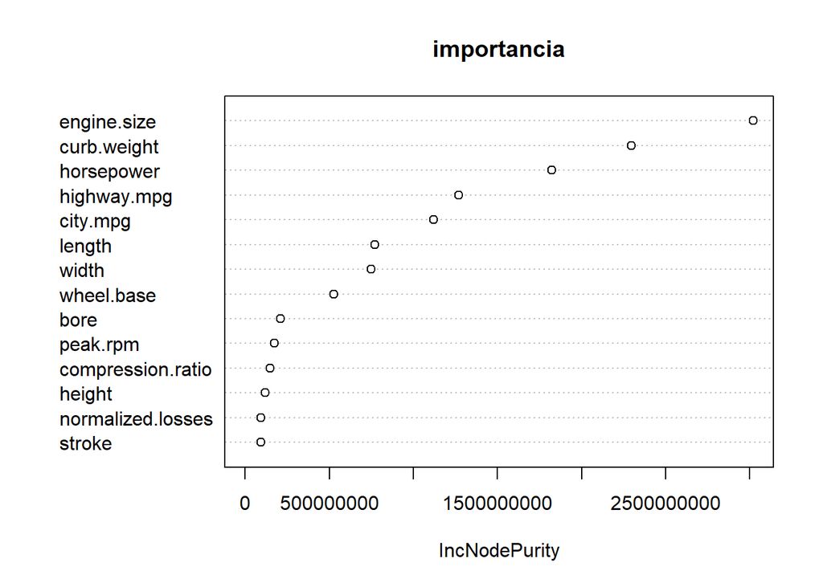

```r
library(randomForest)
importancia  = randomForest(price ~ ., data = t)

col = importance(importancia)
options(scipen=999)
varImpPlot(importancia)
```

Podemos perceber que uma das variáveis removidas anteriormente **engine.size** (cilindradas do motor) possui a maior importância para o modelo , logo,vamos tentar ajustar um modelo com esssa covariável

```r
t2<-t %>%
  dplyr::select(engine.size,curb.weight,horsepower,highway.mpg,city.mpg,length ,price)


# modelo sugerido 1
yu<-glm(price~engine.size+highway.mpg+length , family = Gamma(link=log),data = t2)
summary(yu)
```

```
##
## Call:
## glm(formula = price ~ engine.size + highway.mpg + length, family = Gamma(link = log),
##     data = t2)
##
## Deviance Residuals:
##      Min        1Q    Median        3Q       Max
## -0.58832  -0.16092  -0.05071   0.11449   0.77670
##
## Coefficients:
##               Estimate Std. Error t value             Pr(>|t|)
## (Intercept)  7.5305555  0.4293509  17.539 < 0.0000000000000002 ***
## engine.size  0.0058535  0.0006155   9.511 < 0.0000000000000002 ***
## highway.mpg -0.0198601  0.0038295  -5.186          0.000000522 ***
## length       0.0098396  0.0021535   4.569          0.000008542 ***
## ---
## Signif. codes:  0 '***' 0.001 '**' 0.01 '*' 0.05 '.' 0.1 ' ' 1
##
## (Dispersion parameter for Gamma family taken to be 0.06120744)
##
##     Null deviance: 55.861  on 204  degrees of freedom
## Residual deviance: 11.191  on 201  degrees of freedom
## AIC: 3830.2
##
## Number of Fisher Scoring iterations: 5
```

```r
# modelo sugerido 2
yu2<-glm(price~curb.weight+length , family = Gamma(link=log),data = t2)

summary(yu2)
```

```
##
## Call:
## glm(formula = price ~ curb.weight + length, family = Gamma(link = log),
##     data = t2)
##
## Deviance Residuals:
##      Min        1Q    Median        3Q       Max
## -0.76966  -0.15834  -0.04829   0.06193   1.05941
##
## Coefficients:
##                Estimate  Std. Error t value            Pr(>|t|)
## (Intercept)  7.50654984  0.40039726  18.748 <0.0000000000000002 ***
## curb.weight  0.00092313  0.00007622  12.112 <0.0000000000000002 ***
## length      -0.00280031  0.00321675  -0.871               0.385
## ---
## Signif. codes:  0 '***' 0.001 '**' 0.01 '*' 0.05 '.' 0.1 ' ' 1
##
## (Dispersion parameter for Gamma family taken to be 0.07376687)
##
##     Null deviance: 55.861  on 204  degrees of freedom
## Residual deviance: 12.437  on 202  degrees of freedom
## AIC: 3850
##
## Number of Fisher Scoring iterations: 4
```

### Modelo Binomial Negativo

```r
require(MASS)
mod.nb <- glm.nb(price~., data = novo)

summary(mod.nb)
```

```
##
## Call:
## glm.nb(formula = price ~ ., data = novo, init.theta = 14.18961524,
##     link = log)
##
## Deviance Residuals:
##     Min       1Q   Median       3Q      Max
## -6.0389  -0.7081  -0.1993   0.5592   2.5399
##
## Coefficients:
##                      Estimate  Std. Error z value             Pr(>|z|)
## (Intercept)        8.47508193  0.25571653  33.142 < 0.0000000000000002 ***
## normalized.losses  0.00086989  0.00060863   1.429              0.15293
## compression.ratio  0.02806643  0.00527721   5.318          0.000000105 ***
## horsepower         0.01152785  0.00048597  23.721 < 0.0000000000000002 ***
## peak.rpm          -0.00013301  0.00004436  -2.998              0.00272 **
## ---
## Signif. codes:  0 '***' 0.001 '**' 0.01 '*' 0.05 '.' 0.1 ' ' 1
##
## (Dispersion parameter for Negative Binomial(14.1896) family taken to be 1)
##
##     Null deviance: 791.77  on 204  degrees of freedom
## Residual deviance: 207.32  on 200  degrees of freedom
## AIC: 3887.7
##
## Number of Fisher Scoring iterations: 1
##
##
##               Theta:  14.19
##           Std. Err.:  1.39
##
##  2 x log-likelihood:  -3875.675
```

```r
# modelo sugerido 2
yu2<-glm(price~curb.weight+length , family = Gamma(link=log),data = t2)

summary(yu2)
```

```
##
## Call:
## glm(formula = price ~ curb.weight + length, family = Gamma(link = log),
##     data = t2)
##
## Deviance Residuals:
##      Min        1Q    Median        3Q       Max
## -0.76966  -0.15834  -0.04829   0.06193   1.05941
##
## Coefficients:
##                Estimate  Std. Error t value            Pr(>|t|)
## (Intercept)  7.50654984  0.40039726  18.748 <0.0000000000000002 ***
## curb.weight  0.00092313  0.00007622  12.112 <0.0000000000000002 ***
## length      -0.00280031  0.00321675  -0.871               0.385
## ---
## Signif. codes:  0 '***' 0.001 '**' 0.01 '*' 0.05 '.' 0.1 ' ' 1
##
## (Dispersion parameter for Gamma family taken to be 0.07376687)
##
##     Null deviance: 55.861  on 204  degrees of freedom
## Residual deviance: 12.437  on 202  degrees of freedom
## AIC: 3850
##
## Number of Fisher Scoring iterations: 4
```

## Tabela de modelos

```r
library(hnp)

ajuste = c('mod', 'mod2','mod3','mod4','yu','yu2','mod.nb')
aic    = c(AIC(mod),AIC(mod2),AIC(mod3),AIC(mod4),AIC(yu),AIC(yu2),AIC(mod.nb))
deviance    = c(deviance(mod),deviance(mod2),deviance(mod3),deviance(mod4),deviance(yu),deviance(yu2),deviance(mod.nb))
#verossimilhanca = c(logLik(glmod1),logLik(glmod2),logLik(glmod3))
df<-data.frame(ajuste, round(aic,2),round(deviance,2))
colnames(df)=c("ajuste","AIC","Deveiance")

df%>% datatable()
```

|  | ajuste | AIC | Deveiance |
| --- | --- | --- | --- |
| 1 | mod | 3782.66 | 7.99 |
| 2 | mod2 | 3887.61 | 14.62 |
| 3 | mod3 | 3912.88 | 16.84 |
| 4 | mod4 | 3913.22 | 16.71 |
| 5 | yu | 3830.17 | 11.19 |
| 6 | yu2 | 3850.02 | 12.44 |
| 7 | mod.nb | 3887.67 | 207.32 |

```r
hnp(yu$residuals, sim = 99,resid.type ='deviance',how.many.out=T ,
    conf = 0.95,scale = T)
```

```
## Half-normal plot with simulated envelope generated assuming the residuals are
##         normally distributed under the null hypothesis.
## Estimated mean: -0.00000000003341102
## Estimated variance: 0.06030734
```

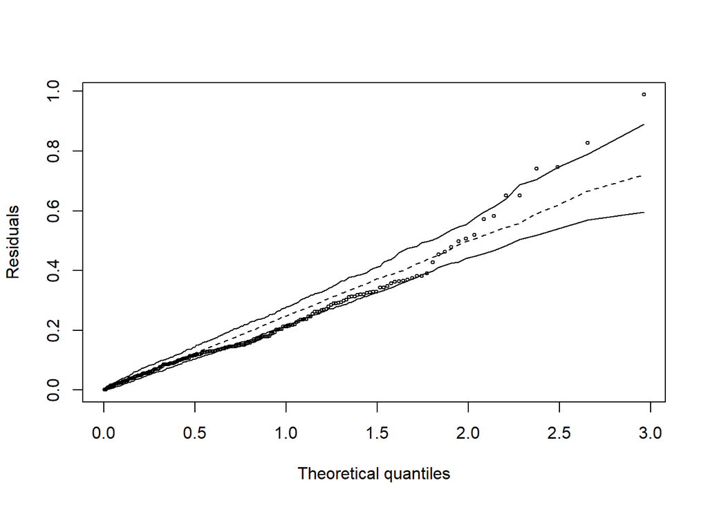

```
## Total points: 205
## Points out of envelope: 50 ( 24.39 %)
```

```r
hnp(mod.nb$residuals, sim = 99,resid.type ='deviance',how.many.out=T ,
    conf = 0.95,scale = T)
```

```
## Half-normal plot with simulated envelope generated assuming the residuals are
##         normally distributed under the null hypothesis.
## Estimated mean: -0.00001070088
## Estimated variance: 0.06639428
```

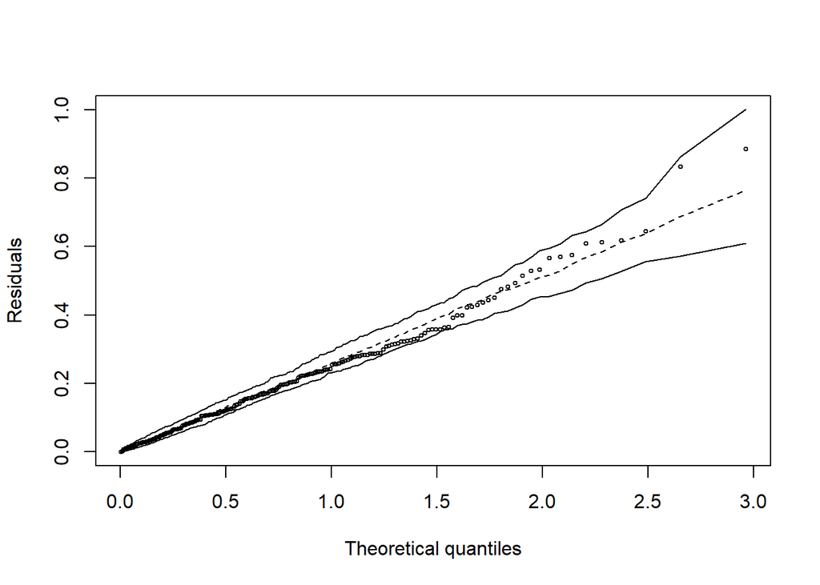

```
## Total points: 205
## Points out of envelope: 0 ( 0 %)
```

```r
# mod<-glm(test$price~.,family = Gamma(link=log),data = test)

 summary(mod2)
```

```
##
## Call:
## glm(formula = price ~ ., family = Gamma(link = log), data = novo)
##
## Deviance Residuals:
##      Min        1Q    Median        3Q       Max
## -1.60361  -0.18808  -0.05306   0.14854   0.67458
##
## Coefficients:
##                      Estimate  Std. Error t value             Pr(>|t|)
## (Intercept)        8.47472093  0.25050641  33.830 < 0.0000000000000002 ***
## normalized.losses  0.00086997  0.00059626   1.459              0.14612
## compression.ratio  0.02806842  0.00517010   5.429          0.000000163 ***
## horsepower         0.01152907  0.00047617  24.212 < 0.0000000000000002 ***
## peak.rpm          -0.00013297  0.00004346  -3.060              0.00252 **
## ---
## Signif. codes:  0 '***' 0.001 '**' 0.01 '*' 0.05 '.' 0.1 ' ' 1
##
## (Dispersion parameter for Gamma family taken to be 0.06771908)
##
##     Null deviance: 55.861  on 204  degrees of freedom
## Residual deviance: 14.625  on 200  degrees of freedom
## AIC: 3887.6
##
## Number of Fisher Scoring iterations: 6
```

```r
library('hnp')
hnp(mod2$residuals, sim = 99,resid.type ='deviance',how.many.out=T ,
    conf = 0.95,scale = T)
```

```
## Half-normal plot with simulated envelope generated assuming the residuals are
##         normally distributed under the null hypothesis.
## Estimated mean: -0.0000000002211503
## Estimated variance: 0.06639125
```

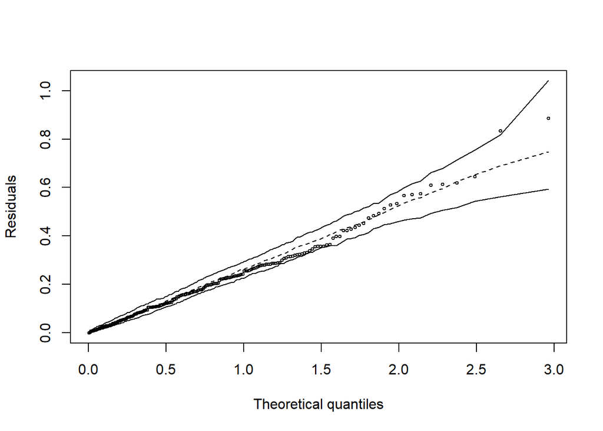

```
## Total points: 205
## Points out of envelope: 1 ( 0.49 %)
```

# Referências

O primeiro automóvel-INFO.Escola , acessado em 10/10/2022 https://www.infoescola.com/curiosidades/historia-do-automovel/

1985 Modelo de Importação de Carro e Especificações de Caminhão, Anuário Automotivo de 1985 Ward.

Personal Auto Manuals, Insurance Services Office, 160 Water Street, Nova York, NY 10038

Insurance Collision Report, Insurance Institute for Highway Safety, Watergate 600, Washington, DC 20037

dados veículos- IBGE ,acessado em 09/10/2022 https://cidades.ibge.gov.br/brasil/pesquisa/22/28120